# Human Activity Detection with Machine Learning

Harish Kumar Rongala

January 29, 2017

## 1. Executive Summary

In this document we try to predict which type of exercise is being done by the person, with data provided by accelerometers. We use machine learning algorithms **rpart**, **gradient boosting** and **random forests** to predict. This document also shows how each model is built, use of cross validation and out of sample errors.

## 2. About Data set

Data set used in this document is an open source data and following paper can be refered to know more about the data.

**Velloso, E.; Bulling, A.; Gellersen, H.; Ugulino, W.; Fuks, H. Qualitative Activity Recognition of Weight Lifting Exercises** [Read more here](http://groupware.les.inf.puc-rio.br/har#ixzz4XOx2aHwx)

Six young health participants were asked to perform one set of 10 repetitions of the Unilateral Dumbbell Biceps Curl in five different fashions: exactly according to the specification (Class A), throwing the elbows to the front (Class B), lifting the dumbbell only halfway (Class C), lowering the dumbbell only halfway (Class D) and throwing the hips to the front (Class E).

## 3. Preparing data

Data is prepared in 3 steps. First, data is loaded in to the working directory. Next, missing values (“NA”/“NaN”) will be handled. Finally, to test the accuracy of our models we need a validation set. So, we divide the data set in to training and validation sets.

### 3.1. Loading data

```r
## Training data url
url1<-"https://d396qusza40orc.cloudfront.net/predmachlearn/pml-training.csv";

## Download and read file
download.file(url1,"HAR_training.csv");
HAR_train<-read.csv("HAR_training.csv",na.strings = c("","NA"));
dim(HAR_train);
```

```
## [1] 19622   160
```

This data set contains 19622 observations and 160 columns.

### 3.2. Cleaning data

There are multiple columns containing missing values. It may not be ideal to impute values here because, these columns are redundant and represent values like maximum, minimum, average, std deviation, variance, amplitude, skewness and kurtosis of the signal. First 7 columns represents values like user id, subject name, timestamp etc. They are unrelated in predicting the type of exercise. So, we drop them as well.

```r
## This variable holds columns to be dropped
drp<-NULL;
##
drp<-append(drp,c(1:7));
drp<-append(drp,grep("^max|^min|^avg|^std|^var|^amp|^skew|^kurt",names(HAR_train)));
## Dropping unwanted columns
HAR_train_clean<-HAR_train[,-drp];
dim(HAR_train_clean);
```

```
## [1] 19622    53
```

After dropping the unwanted columns, our data set contains 53 columns.

### 3.3. Data Slicing

As we intend to create multiple models and test, it is always a good practice to slice our training data in to training and validation set (when data set is large enough). Here, the **70%** of training set is labeled as training set and **30%** is labeled as validation set.

```r
## Creating training and validation sets
suppressPackageStartupMessages(library(caret));
## Set seed for reproducibility
set.seed(1225);
ind<-createDataPartition(HAR_train_clean$classe,p=0.7,list=FALSE);
train_set<-HAR_train_clean[ind,];
valid_set<-HAR_train_clean[-ind,];

dim(train_set);
```

```
## [1] 13737    53
```

```r
dim(valid_set);
```

```
## [1] 5885   53
```

## 4. Model fitting

We start with a **rpart** tree classification and end with **gradient boosting method** and **random forests method**. Cross validation is performed with K-fold method, K being 10. This ensures accuracy of the model by training and testing on every observation of the training set and averaging the accuracies.

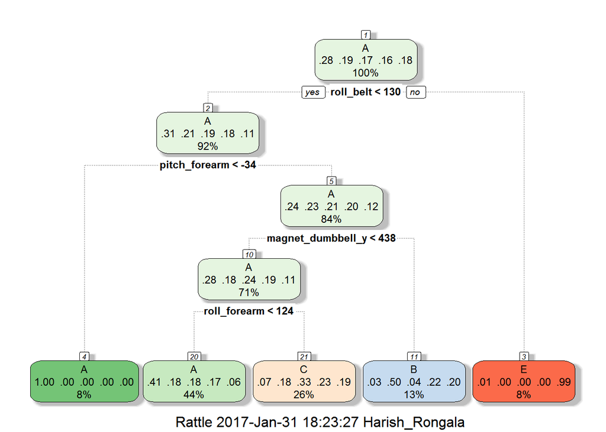

```r
## Set seed for reproducibility
set.seed(1225);
tr_ctrl<-trainControl(method="cv", savePredictions = TRUE, classProbs = TRUE);
## Using rpart classifier
suppressPackageStartupMessages(fit0<-train(classe~.,data=train_set,method="rpart",trControl=tr_ctrl));

## Look at the model
suppressPackageStartupMessages(library(rattle));
fancyRpartPlot(fit0$finalModel);
```

```r
## Set seed for reproducibility
set.seed(1225);
## Fit Gradient Boosting method
fit1<-train(classe~.,data=train_set,method="gbm",trControl=tr_ctrl);
```

```r
## Set seed for reproducibility
set.seed(1225);
## Fit using Random Forests
fit2<-train(classe~.,data=train_set,method="rf",trControl=tr_ctrl);
rf_ind<-fit2$pred$mtry==2;
```

## 5. Prediction

### 5.1. Prediction on Validation set

```r
## Predict using rpart classifier
suppressPackageStartupMessages(rpart_pr<-predict(fit0,valid_set));
## Predict using Gradient boosting model
suppressPackageStartupMessages(gbm_pr<-predict(fit1,valid_set));
## Predict using Random Forest model
suppressPackageStartupMessages(rf_pr<-predict(fit2,valid_set));

## Look at the accuracy
confusionMatrix(rpart_pr,valid_set$classe);
```

```
## Confusion Matrix and Statistics
##
##           Reference
## Prediction    A    B    C    D    E
##          A 1512  471  478  434  147
##          B   29  384   31  169  132
##          C  130  284  517  361  296
##          D    0    0    0    0    0
##          E    3    0    0    0  507
##
## Overall Statistics
##
##                Accuracy : 0.4962
##                  95% CI : (0.4833, 0.509)
##     No Information Rate : 0.2845
##     P-Value [Acc > NIR] : < 2.2e-16
##
##                   Kappa : 0.3418
##  Mcnemar's Test P-Value : NA
##
## Statistics by Class:
##
##                      Class: A Class: B Class: C Class: D Class: E
## Sensitivity            0.9032  0.33714  0.50390   0.0000  0.46858
## Specificity            0.6367  0.92394  0.77958   1.0000  0.99938
## Pos Pred Value         0.4970  0.51544  0.32557      NaN  0.99412
## Neg Pred Value         0.9430  0.85311  0.88155   0.8362  0.89302
## Prevalence             0.2845  0.19354  0.17434   0.1638  0.18386
## Detection Rate         0.2569  0.06525  0.08785   0.0000  0.08615
## Detection Prevalence   0.5169  0.12659  0.26984   0.0000  0.08666
## Balanced Accuracy      0.7699  0.63054  0.64174   0.5000  0.73398
```

```r
confusionMatrix(gbm_pr,valid_set$classe);
```

```
## Confusion Matrix and Statistics
##
##           Reference
## Prediction    A    B    C    D    E
##          A 1654   31    0    2    2
##          B   11 1058   35    3   12
##          C    6   47  978   32    4
##          D    3    3    9  918   15
##          E    0    0    4    9 1049
##
## Overall Statistics
##
##                Accuracy : 0.9613
##                  95% CI : (0.956, 0.966)
##     No Information Rate : 0.2845
##     P-Value [Acc > NIR] : < 2.2e-16
##
##                   Kappa : 0.951
##  Mcnemar's Test P-Value : 1.506e-06
##
## Statistics by Class:
##
##                      Class: A Class: B Class: C Class: D Class: E
## Sensitivity            0.9881   0.9289   0.9532   0.9523   0.9695
## Specificity            0.9917   0.9871   0.9817   0.9939   0.9973
## Pos Pred Value         0.9793   0.9455   0.9166   0.9684   0.9878
## Neg Pred Value         0.9952   0.9830   0.9900   0.9907   0.9932
## Prevalence             0.2845   0.1935   0.1743   0.1638   0.1839
## Detection Rate         0.2811   0.1798   0.1662   0.1560   0.1782
## Detection Prevalence   0.2870   0.1901   0.1813   0.1611   0.1805
## Balanced Accuracy      0.9899   0.9580   0.9674   0.9731   0.9834
```

```r
confusionMatrix(rf_pr,valid_set$classe);
```

```
## Confusion Matrix and Statistics
##
##           Reference
## Prediction    A    B    C    D    E
##          A 1671    4    0    0    0
##          B    3 1132    5    0    0
##          C    0    3 1021   19    1
##          D    0    0    0  944    2
##          E    0    0    0    1 1079
##
## Overall Statistics
##
##                Accuracy : 0.9935
##                  95% CI : (0.9911, 0.9954)
##     No Information Rate : 0.2845
##     P-Value [Acc > NIR] : < 2.2e-16
##
##                   Kappa : 0.9918
##  Mcnemar's Test P-Value : NA
##
## Statistics by Class:
##
##                      Class: A Class: B Class: C Class: D Class: E
## Sensitivity            0.9982   0.9939   0.9951   0.9793   0.9972
## Specificity            0.9991   0.9983   0.9953   0.9996   0.9998
## Pos Pred Value         0.9976   0.9930   0.9780   0.9979   0.9991
## Neg Pred Value         0.9993   0.9985   0.9990   0.9960   0.9994
## Prevalence             0.2845   0.1935   0.1743   0.1638   0.1839
## Detection Rate         0.2839   0.1924   0.1735   0.1604   0.1833
## Detection Prevalence   0.2846   0.1937   0.1774   0.1607   0.1835
## Balanced Accuracy      0.9986   0.9961   0.9952   0.9894   0.9985
```

### 5.2. Look at the ROC

```r
par(mfrow=c(2,3));
plot(p1);
```

```
##
## Call:
## roc.default(response = fit2$pred$obs[rf_ind], predictor = fit2$pred$A[rf_ind])
##
## Data: fit2$pred$A[rf_ind] in 3906 controls (fit2$pred$obs[rf_ind] A) > 2658 cases (fit2$pred$obs[rf_ind] B).
## Area under the curve: 0.9998
```

```r
plot(p2);
```

```
##
## Call:
## roc.default(response = fit2$pred$obs[rf_ind], predictor = fit2$pred$B[rf_ind])
##
## Data: fit2$pred$B[rf_ind] in 3906 controls (fit2$pred$obs[rf_ind] A) < 2658 cases (fit2$pred$obs[rf_ind] B).
## Area under the curve: 1
```

```r
plot(p3);
```

```
##
## Call:
## roc.default(response = fit2$pred$obs[rf_ind], predictor = fit2$pred$C[rf_ind])
##
## Data: fit2$pred$C[rf_ind] in 3906 controls (fit2$pred$obs[rf_ind] A) < 2658 cases (fit2$pred$obs[rf_ind] B).
## Area under the curve: 0.7218
```

```r
plot(p4);
```

```
##
## Call:
## roc.default(response = fit2$pred$obs[rf_ind], predictor = fit2$pred$D[rf_ind])
##
## Data: fit2$pred$D[rf_ind] in 3906 controls (fit2$pred$obs[rf_ind] A) < 2658 cases (fit2$pred$obs[rf_ind] B).
## Area under the curve: 0.6877
```

```
##
## Call:
## roc.default(response = fit2$pred$obs[rf_ind], predictor = fit2$pred$E[rf_ind])
##
## Data: fit2$pred$E[rf_ind] in 3906 controls (fit2$pred$obs[rf_ind] A) < 2658 cases (fit2$pred$obs[rf_ind] B).
## Area under the curve: 0.835
```

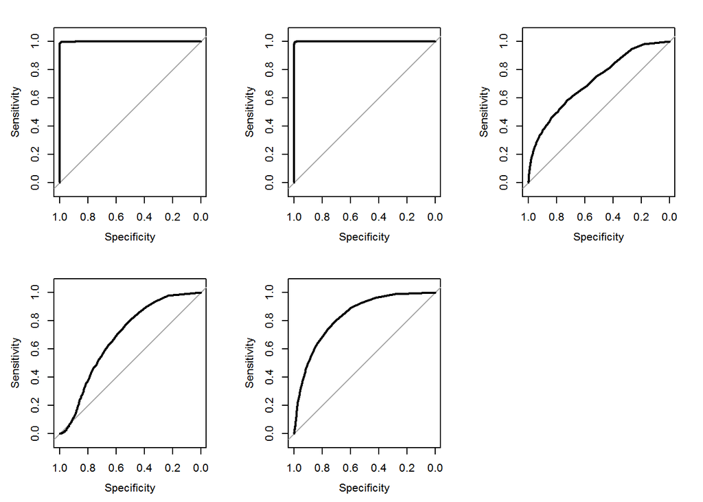

```r
plot(p5);
```

### 5.3. Prediction on Test set

```r
## Testing data url
url2<-"https://d396qusza40orc.cloudfront.net/predmachlearn/pml-testing.csv";
download.file(url2,"HAR_test.csv");
HAR_test<-read.csv("HAR_test.csv");

test_pr_rpart<-predict(fit0,HAR_test);
test_pr_gbm<-predict(fit1,HAR_test);
test_pr_rf<-predict(fit2,HAR_test);

test_pr_rpart;
```

```
##  [1] C A C A A C C A A A C C C A C A A A A C
## Levels: A B C D E
```

```r
test_pr_gbm;
```

```
##  [1] B A B A A E D B A A B C B A E E A B B B
## Levels: A B C D E
```

```r
test_pr_rf;
```

```
##  [1] B A B A A E D B A A B C B A E E A B B B
## Levels: A B C D E
```

## 6. Conclusion

- Out of sample error of rpart classifier is 0.5038
- Out of sample error of Gradient Boosting Model is 0.0387
- Out of sample error of Random Forest model is 0.0065
- In this case, prediction on test set is same for GBM and Random Forests. However, considering the error rate, we submit the Random forests model as our final model.

## 7. Appendix

ROC code

```r
library(pROC);
rf_ind<-fit2$pred$mtry==2;
suppressMessages(library(pROC));
p1<-roc(fit2$pred$obs[rf_ind],fit2$pred$A[rf_ind]);
p2<-roc(fit2$pred$obs[rf_ind],fit2$pred$B[rf_ind]);
p3<-roc(fit2$pred$obs[rf_ind],fit2$pred$C[rf_ind]);
p4<-roc(fit2$pred$obs[rf_ind],fit2$pred$D[rf_ind]);
p5<-roc(fit2$pred$obs[rf_ind],fit2$pred$E[rf_ind]);
```